# Diastolic blood pressure

# 1 Description of DataSchema variable

The description of harmonised variable is the following:

- Short name: `dbp`
- Variable label: `Diastolic blood pressure of participant at each wave`
- Variable description: `Means of all diastolic blood pressure measures.`
- Domain: `Physical measures`
- Value type: `Continuous`
- Category missings:

| **Code** | **Category Label** |
| --- | --- |
| 991 | CAPI/interviewer error |
| 992 | Impute |
| 993 | Disable to measure |
| 994 | Not attempt/not done |
| 995 | Does not answer |
| 996 | Not applicable |
| 997 | Refuse |
| 998 | Do not know |
| 999 | Missing |

# 2 Data process

## 2.1 England

### 2.1.1 Wave 1

There is no variable.

### 2.1.2 Wave 2

#### 2.1.2.1 Study-specific variable description

The study-specific variable elected to be harmonised is:

- Name: `dias1`
- Label: `BP: 1st diastolic reading (mmHg)`
- Type of variable: `countinous`
- Missings
  - `-9 = No answer/Refusal`
  - `-8 = Dont know`
  - `-3 = Error reading`
  - `-2 = No reading obtained`
  - `-1 = Not Applicable`
- Name: `dias2`
- Label: `BP: 2nd diastolic reading (mmHg)`
- Type of variable: `countinous`
- Missings
  - `-9 = No answer/Refusal`
  - `-8 = Dont know`
  - `-3 = Error reading`
  - `-2 = No reading obtained`
  - `-1 = Not Applicable`
- Name: `dias3`
- Label: `BP: 3rd diastolic reading (mmHg)`
- Type of variable: `countinous`
- Missings
  - `-9 = No answer/Refusal`
  - `-8 = Dont know`
  - `-3 = Error reading`
  - `-2 = No reading obtained`
  - `-1 = Not Applicable`

```
## $summary
##    Min. 1st Qu.  Median    Mean 3rd Qu.    Max.
##    37.0    68.0    76.0    76.3    84.0   135.0
##
## $values_table
##            No-missings -9 -8 -3    -2    -1 NA
## Frequency      7557.00  0  0  0 85.00 24.00  0
## Percentage       98.58  0  0  0  1.11  0.31  0
##
## $n_table
##      Sample size Missing values
## [1,]        7666            109
```

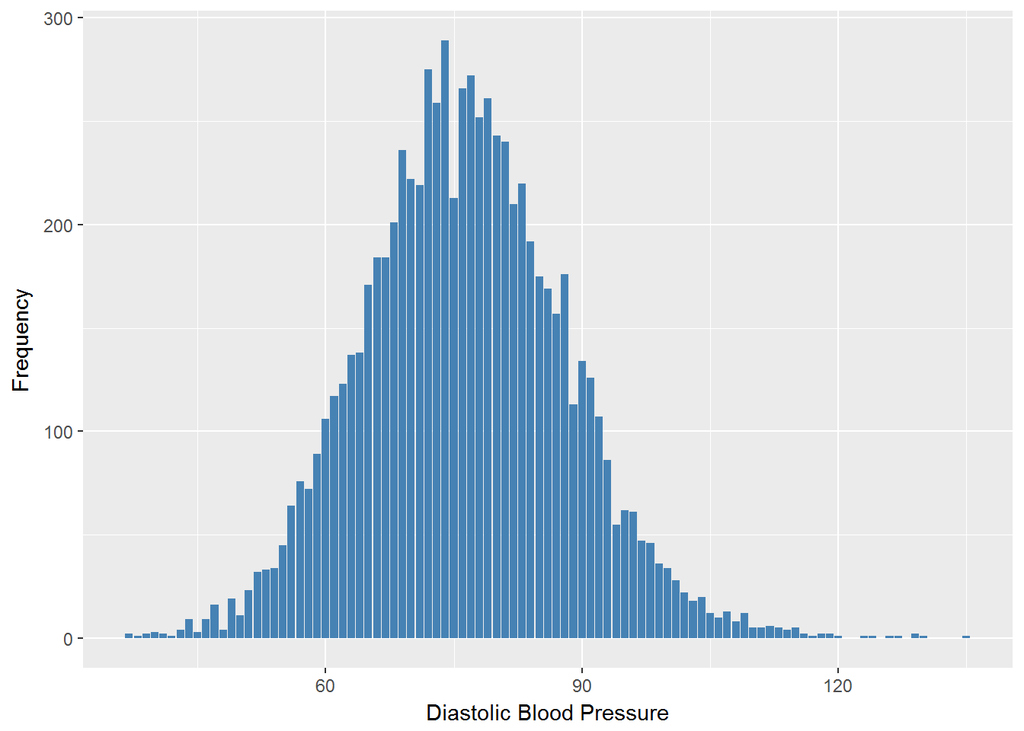

```
## $summary
##    Min. 1st Qu.  Median    Mean 3rd Qu.    Max.
##   31.00   67.00   75.00   75.19   83.00  129.00
##
## $values_table
##            No-missings -9 -8 -3     -2    -1 NA
## Frequency      7525.00  0  0  0 117.00 24.00  0
## Percentage       98.16  0  0  0   1.53  0.31  0
##
## $n_table
##      Sample size Missing values
## [1,]        7666            141
```

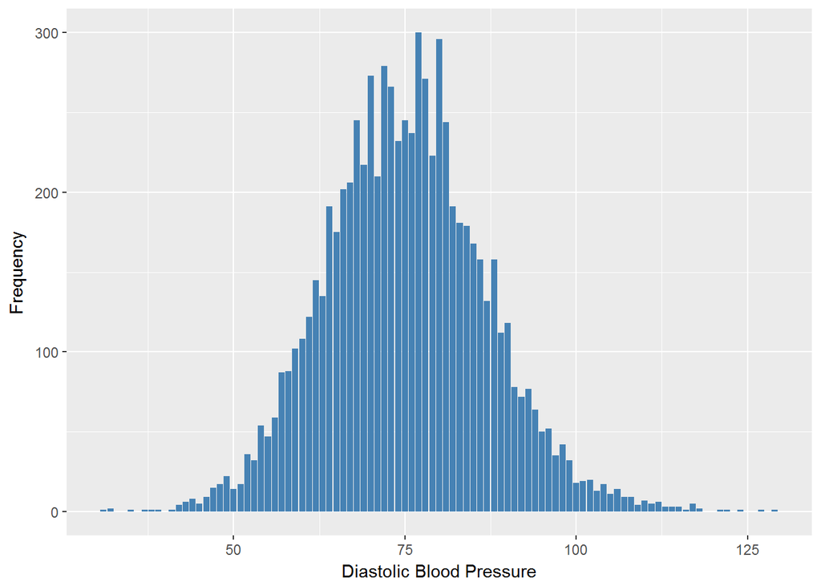

```
## $summary
##    Min. 1st Qu.  Median    Mean 3rd Qu.    Max.
##   35.00   67.00   75.00   74.84   82.00  129.00
##
## $values_table
##            No-missings -9 -8 -3  -2    -1 NA
## Frequency      7489.00  0  0  0 153 24.00  0
## Percentage       97.69  0  0  0   2  0.31  0
##
## $n_table
##      Sample size Missing values
## [1,]        7666            177
```

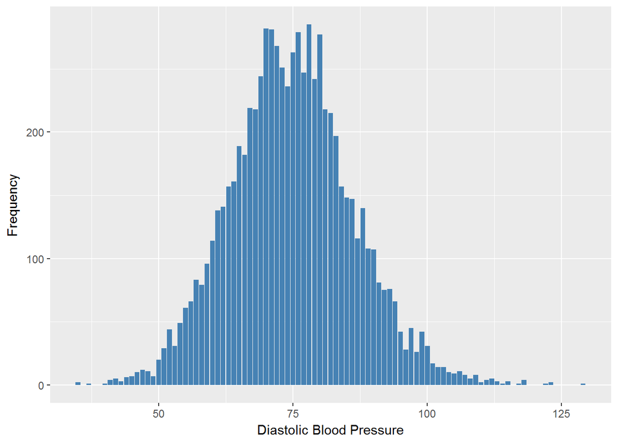

#### 2.1.2.2 Harmonisation algorithm

- `recode -9 "No answer/Refusal" into 995`
- `recode -8 "Dont know" into 998`
- `recode -3 "Error reading" into 991`
- `recode -2 "No reading obtained" into 999`
- `recode -1 "Not Applicable" into 996`
- `NA into 999`

**R script:**

```r
ELSA_w2_dbp$mean_dbp <- apply(X = ELSA_w2_dbp[, c(2, 3)], MARGIN = 1, FUN = mean)

### -2 only in the first one
id2_only01 <- which(ELSA_w2_dbp$dias1 == -2 & ELSA_w2_dbp$dias2 != -2 & ELSA_w2_dbp$dias3 !=
    -2)

ELSA_w2_dbp$mean_dbp[id2_only01] <- apply(X = ELSA_w2_dbp[id2_only01, c(3, 4)],
    MARGIN = 1, FUN = mean)

### -2 only in the third one
id2_only03 <- which(ELSA_w2_dbp$dias1 != -2 & ELSA_w2_dbp$dias2 != -2 & ELSA_w2_dbp$dias3 ==
    -2)

ELSA_w2_dbp$mean_dbp[id2_only03] <- apply(X = ELSA_w2_dbp[id2_only03, c(2, 3)],
    MARGIN = 1, FUN = mean)

### -2 in the first and second one
id2_01_02 <- which(ELSA_w2_dbp$dias1 == -2 & ELSA_w2_dbp$dias2 == -2 & ELSA_w2_dbp$dias3 !=
    -2)

ELSA_w2_dbp$mean_dbp[id2_01_02] <- ELSA_w2_dbp$dias3[id2_01_02]

### -2 in the first and third one
id2_01_03 <- which(ELSA_w2_dbp$dias1 == -2 & ELSA_w2_dbp$dias2 != -2 & ELSA_w2_dbp$dias3 ==
    -2)

ELSA_w2_dbp$mean_dbp[id2_01_03] <- ELSA_w2_dbp$dias2[id2_01_03]

### -2 in the second and third one
id2_02_03 <- which(ELSA_w2_dbp$dias1 != -2 & ELSA_w2_dbp$dias2 == -2 & ELSA_w2_dbp$dias3 ==
    -2)

ELSA_w2_dbp$mean_dbp[id2_02_03] <- ELSA_w2_dbp$dias1[id2_02_03]





ELSA_ds_w2 <- tibble(id = ELSA_w2_dbp$id)
ELSA_ds_w2$dbp <- car::recode(ELSA_w2_dbp$mean_dbp, "NA=999; -9=995; -8=998; -3=991; -2=999; -1=996")
ELSA_ds_w2$dbp <- labelled(ELSA_ds_w2$dbp, labels = c(Missing = 999, `Do not know` = 998,
    Refuse = 997, `Not applicable` = 996, `Does not answer` = 995, `Not attempt not done` = 994,
    `Disable to measure` = 993, Impute = 992, `CAPI interviewer error` = 991))
```

#### 2.1.2.3 Statistics of the new harmonised variable

```
## $summary
##    Min. 1st Qu.  Median    Mean 3rd Qu.    Max.
##   32.00   68.00   75.50   75.76   83.00  128.00
##
## $values_table
##            No-missings 991 992 993 994 995   996 997 998   999 NA
## Frequency      7563.00   0   0   0   0   0 24.00   0   0 79.00  0
## Percentage       98.66   0   0   0   0   0  0.31   0   0  1.03  0
##
## $n_table
##      Sample size Missing values
## [1,]        7666            103
```

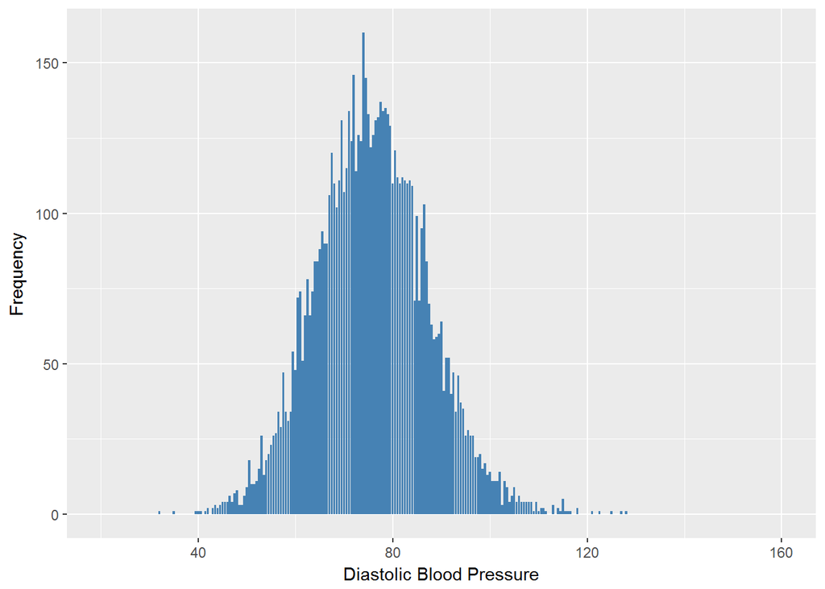

#### 2.1.2.4 Validation

```r
# val_labels(ELSA_ds_w2) <- NULL opal.assign.data(o, 'ELSA_ds_w2',
# ELSA_ds_w2) opal.symbol_import(o,'ELSA_ds_w2',
# project='_Athlos_Harm_Dataset')
```

### 2.1.3 Wave 3

There is no variable.

### 2.1.4 Wave 4

#### 2.1.4.1 Study-specific variable description

The study-specific variable elected to be harmonised is:

- Name: `dias1`
- Label: `BP: 1st diastolic reading (mmHg)`
- Type of variable: `countinous`
- Missings
  - `-1 = Not Applicable`
  - `999 = Reading not obtained`
- Name: `dias2`
- Label: `BP: 2nd diastolic reading (mmHg)`
- Type of variable: `countinous`
- Missings
  - `-1 = Not Applicable`
  - `999 = Reading not obtained`
- Name: `dias3`
- Label: `BP: 3rd diastolic reading (mmHg)`
- Type of variable: `countinous`
- Missings
  - `-1 = Not Applicable`
  - `999 = Reading not obtained`

```
## $summary
##    Min. 1st Qu.  Median    Mean 3rd Qu.    Max.
##   38.00   68.00   75.00   75.42   83.00  127.00
##
## $values_table
##            No-missings    -1   999 NA
## Frequency       8531.0 37.00 75.00  0
## Percentage        98.7  0.43  0.87  0
##
## $n_table
##      Sample size Missing values
## [1,]        8643            112
```

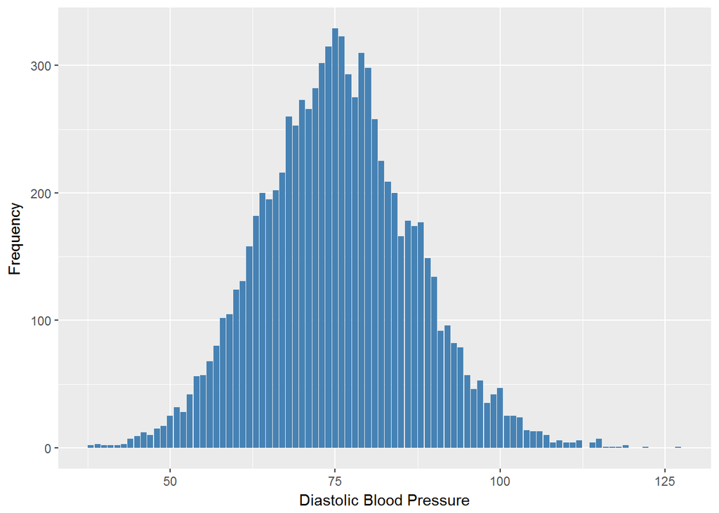

```
## $summary
##    Min. 1st Qu.  Median    Mean 3rd Qu.    Max.
##   33.00   67.00   74.00   74.43   82.00  123.00
##
## $values_table
##            No-missings    -1    999 NA
## Frequency      8493.00 37.00 113.00  0
## Percentage       98.26  0.43   1.31  0
##
## $n_table
##      Sample size Missing values
## [1,]        8643            150
```

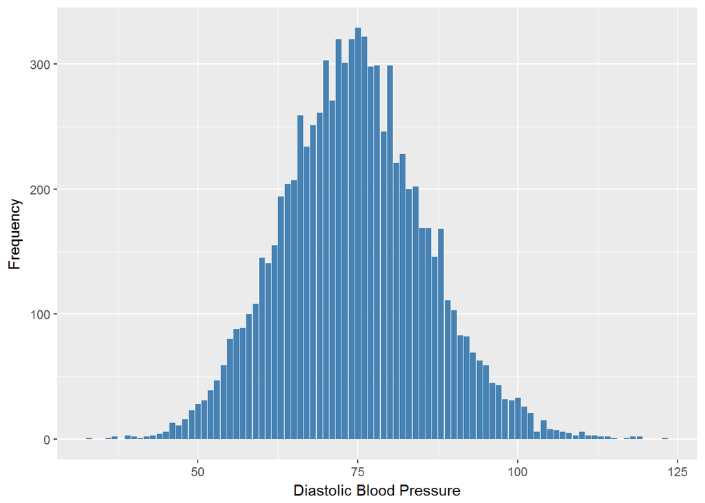

```
## $summary
##    Min. 1st Qu.  Median    Mean 3rd Qu.    Max.
##   33.00   67.00   74.00   74.08   81.00  127.00
##
## $values_table
##            No-missings    -1    999 NA
## Frequency      8440.00 37.00 166.00  0
## Percentage       97.65  0.43   1.92  0
##
## $n_table
##      Sample size Missing values
## [1,]        8643            203
```

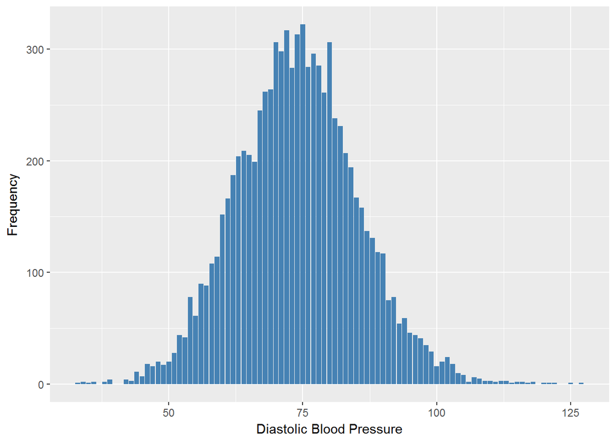

#### 2.1.4.2 Harmonisation algorithm

- `keep "Reading not obtained" into 999`
- `recode -1 "Not Applicable" into 996`
- `NA into 999`

**R script:**

```r
ELSA_w4_dbp$dias1 <- car::recode(ELSA_w4_dbp$dias1, "999=-2")
ELSA_w4_dbp$dias2 <- car::recode(ELSA_w4_dbp$dias2, "999=-2")
ELSA_w4_dbp$dias3 <- car::recode(ELSA_w4_dbp$dias3, "999=-2")

ELSA_w4_dbp$mean_dbp <- apply(X = ELSA_w4_dbp[, c(2, 3)], MARGIN = 1, FUN = mean)

### -2 only in the first one
id2_only01 <- which(ELSA_w4_dbp$dias1 == -2 & ELSA_w4_dbp$dias2 != -2 & ELSA_w4_dbp$dias3 !=
    -2)

ELSA_w4_dbp$mean_dbp[id2_only01] <- apply(X = ELSA_w4_dbp[id2_only01, c(3, 4)],
    MARGIN = 1, FUN = mean)

### -2 only in the second one
id2_only02 <- which(ELSA_w4_dbp$dias1 != -2 & ELSA_w4_dbp$dias2 == -2 & ELSA_w4_dbp$dias3 !=
    -2)

ELSA_w4_dbp$mean_dbp[id2_only02] <- apply(X = ELSA_w4_dbp[id2_only02, c(2, 4)],
    MARGIN = 1, FUN = mean)

### -2 only in the third one
id2_only03 <- which(ELSA_w4_dbp$dias1 != -2 & ELSA_w4_dbp$dias2 != -2 & ELSA_w4_dbp$dias3 ==
    -2)

ELSA_w4_dbp$mean_dbp[id2_only03] <- apply(X = ELSA_w4_dbp[id2_only03, c(2, 3)],
    MARGIN = 1, FUN = mean)

### -2 in the first and second one
id2_01_02 <- which(ELSA_w4_dbp$dias1 == -2 & ELSA_w4_dbp$dias2 == -2 & ELSA_w4_dbp$dias3 !=
    -2)

ELSA_w4_dbp$mean_dbp[id2_01_02] <- ELSA_w4_dbp$dias3[id2_01_02]

### -2 in the second and third one
id2_02_03 <- which(ELSA_w4_dbp$dias1 != -2 & ELSA_w4_dbp$dias2 == -2 & ELSA_w4_dbp$dias3 ==
    -2)

ELSA_w4_dbp$mean_dbp[id2_02_03] <- ELSA_w4_dbp$dias1[id2_02_03]





ELSA_ds_w4 <- tibble(id = ELSA_w4_dbp$id)
ELSA_ds_w4$dbp <- car::recode(ELSA_w4_dbp$mean_dbp, "NA=999; -2=999; -1=996")
ELSA_ds_w4$dbp <- labelled(ELSA_ds_w4$dbp, labels = c(Missing = 999, `Do not know` = 998,
    Refuse = 997, `Not applicable` = 996, `Does not answer` = 995, `Not attempt not done` = 994,
    `Disable to measure` = 993, Impute = 992, `CAPI interviewer error` = 991))
```

#### 2.1.4.3 Statistics of the new harmonised variable

```
## $summary
##    Min. 1st Qu.  Median    Mean 3rd Qu.    Max.
##   37.50   67.50   74.50   74.92   82.00  122.50
##
## $values_table
##            No-missings 991 992 993 994 995   996 997 998  999 NA
## Frequency      8537.00   0   0   0   0   0 37.00   0   0 69.0  0
## Percentage       98.77   0   0   0   0   0  0.43   0   0  0.8  0
##
## $n_table
##      Sample size Missing values
## [1,]        8643            106
```

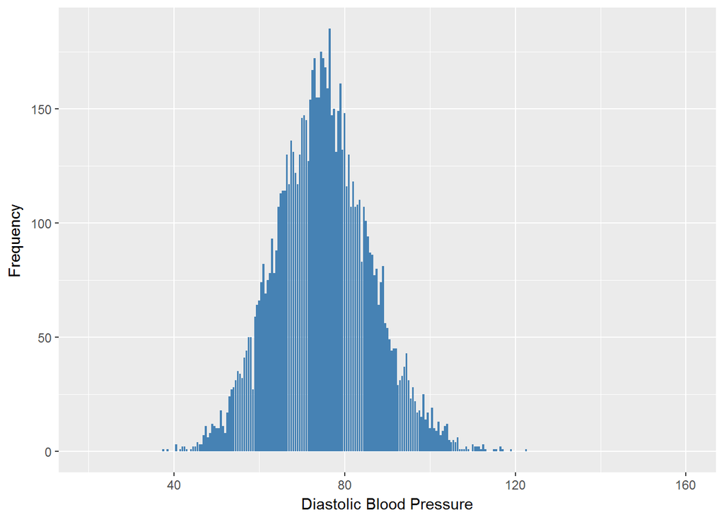

#### 2.1.4.4 Validation

### 2.1.5 Wave 5

There is no variable.

### 2.1.6 Wave 6

#### 2.1.6.1 Study-specific variable description

The study-specific variable elected to be harmonised is:

- Name: `dias1`
- Label: `BP: 1st diastolic reading (mmHg)`
- Type of variable: `countinous`
- Missings
  - `-1 = Not Applicable`
  - `999 = Reading not obtained`
- Name: `dias2`
- Label: `BP: 2nd diastolic reading (mmHg)`
- Type of variable: `countinous`
- Missings
  - `-1 = Not Applicable`
  - `999 = Reading not obtained`
- Name: `dias3`
- Label: `BP: 3rd diastolic reading (mmHg)`
- Type of variable: `countinous`
- Missings
  - `-1 = Not Applicable`
  - `999 = Reading not obtained`

```
## $summary
##    Min. 1st Qu.  Median    Mean 3rd Qu.    Max.
##   34.00   67.00   74.00   74.66   82.00  129.00
##
## $values_table
##            No-missings    -1   999 NA
## Frequency      7974.00 25.00 55.00  0
## Percentage       99.01  0.31  0.68  0
##
## $n_table
##      Sample size Missing values
## [1,]        8054             80
```

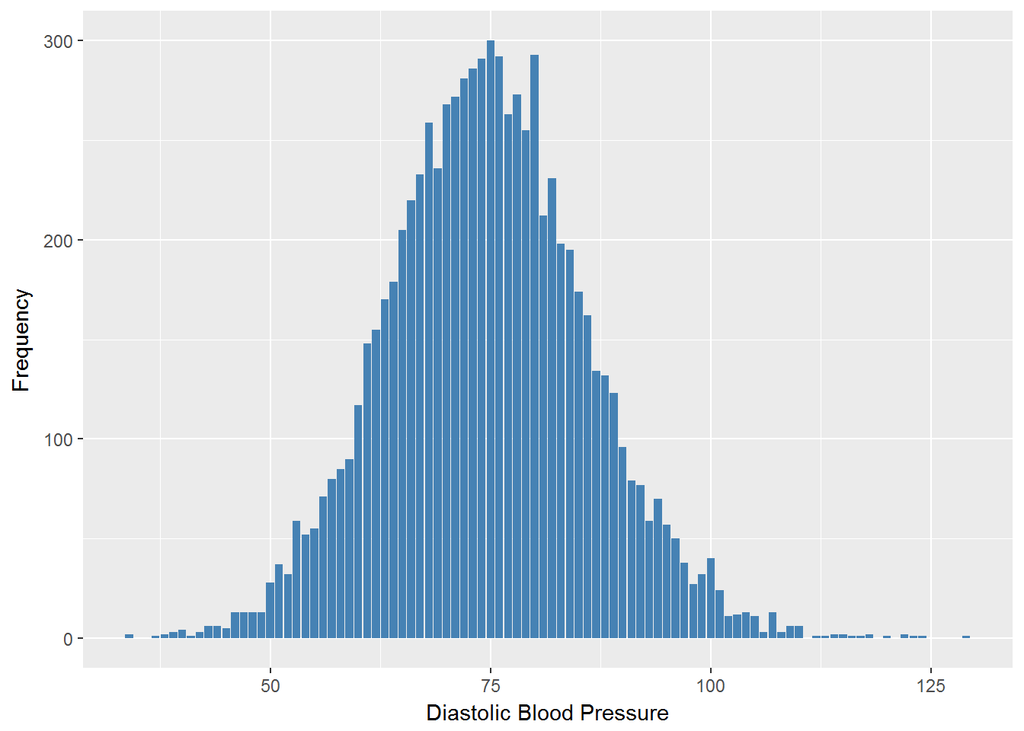

```
## $summary
##    Min. 1st Qu.  Median    Mean 3rd Qu.    Max.
##   31.00   66.00   74.00   73.74   81.00  121.00
##
## $values_table
##            No-missings    -1   999 NA
## Frequency      7930.00 25.00 99.00  0
## Percentage       98.46  0.31  1.23  0
##
## $n_table
##      Sample size Missing values
## [1,]        8054            124
```

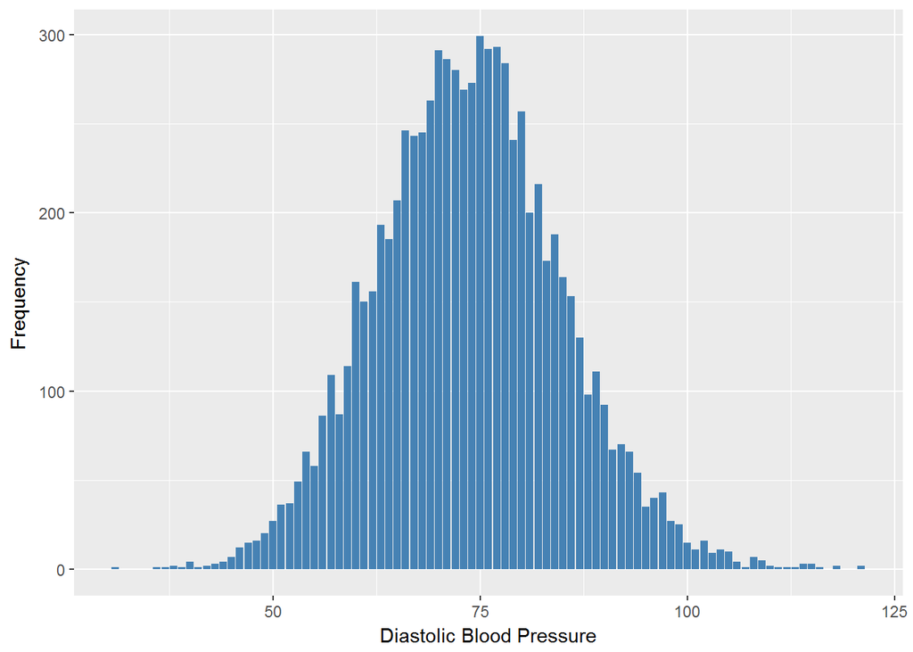

```
## $summary
##    Min. 1st Qu.  Median    Mean 3rd Qu.    Max.
##    31.0    66.0    73.0    73.4    81.0   139.0
##
## $values_table
##            No-missings    -1    999 NA
## Frequency         7893 25.00 136.00  0
## Percentage          98  0.31   1.69  0
##
## $n_table
##      Sample size Missing values
## [1,]        8054            161
```

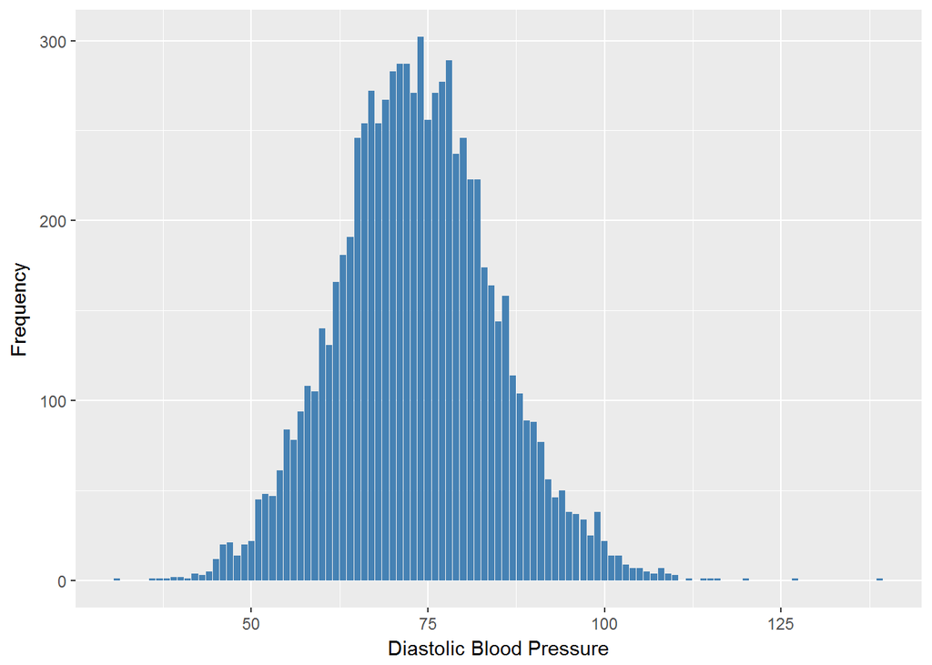

#### 2.1.6.2 Harmonisation algorithm

- `keep "Reading not obtained" into 999`
- `recode -1 "Not Applicable" into 996`
- `NA into 999`

**R script:**

```r
ELSA_w6_dbp$dias1 <- car::recode(ELSA_w6_dbp$dias1, "999=-2")
ELSA_w6_dbp$dias2 <- car::recode(ELSA_w6_dbp$dias2, "999=-2")
ELSA_w6_dbp$dias3 <- car::recode(ELSA_w6_dbp$dias3, "999=-2")

ELSA_w6_dbp$mean_dbp <- apply(X = ELSA_w6_dbp[, c(2, 3)], MARGIN = 1, FUN = mean)

### -2 only in the second one
id2_only02 <- which(ELSA_w6_dbp$dias1 != -2 & ELSA_w6_dbp$dias2 == -2 & ELSA_w6_dbp$dias3 !=
    -2)

ELSA_w6_dbp$mean_dbp[id2_only02] <- apply(X = ELSA_w6_dbp[id2_only02, c(2, 4)],
    MARGIN = 1, FUN = mean)

### -2 only in the third one
id2_only03 <- which(ELSA_w6_dbp$dias1 != -2 & ELSA_w6_dbp$dias2 != -2 & ELSA_w6_dbp$dias3 ==
    -2)

ELSA_w6_dbp$mean_dbp[id2_only03] <- apply(X = ELSA_w6_dbp[id2_only03, c(2, 3)],
    MARGIN = 1, FUN = mean)

### -2 in the second and third one
id2_02_03 <- which(ELSA_w6_dbp$dias1 != -2 & ELSA_w6_dbp$dias2 == -2 & ELSA_w6_dbp$dias3 ==
    -2)

ELSA_w6_dbp$mean_dbp[id2_02_03] <- ELSA_w6_dbp$dias1[id2_02_03]


ELSA_ds_w6 <- tibble(id = ELSA_w6_dbp$id)
ELSA_ds_w6$dbp <- car::recode(ELSA_w6_dbp$mean_dbp, "NA=999; -2=999; -1=996")
ELSA_ds_w6$dbp <- labelled(ELSA_ds_w6$dbp, labels = c(Missing = 999, `Do not know` = 998,
    Refuse = 997, `Not applicable` = 996, `Does not answer` = 995, `Not attempt not done` = 994,
    `Disable to measure` = 993, Impute = 992, `CAPI interviewer error` = 991))
```

#### 2.1.6.3 Statistics of the new harmonised variable

```
## $summary
##    Min. 1st Qu.  Median    Mean 3rd Qu.    Max.
##   35.50   67.00   74.00   74.21   81.50  125.00
##
## $values_table
##            No-missings 991 992 993 994 995   996 997 998   999 NA
## Frequency      7974.00   0   0   0   0   0 25.00   0   0 55.00  0
## Percentage       99.01   0   0   0   0   0  0.31   0   0  0.68  0
##
## $n_table
##      Sample size Missing values
## [1,]        8054             80
```

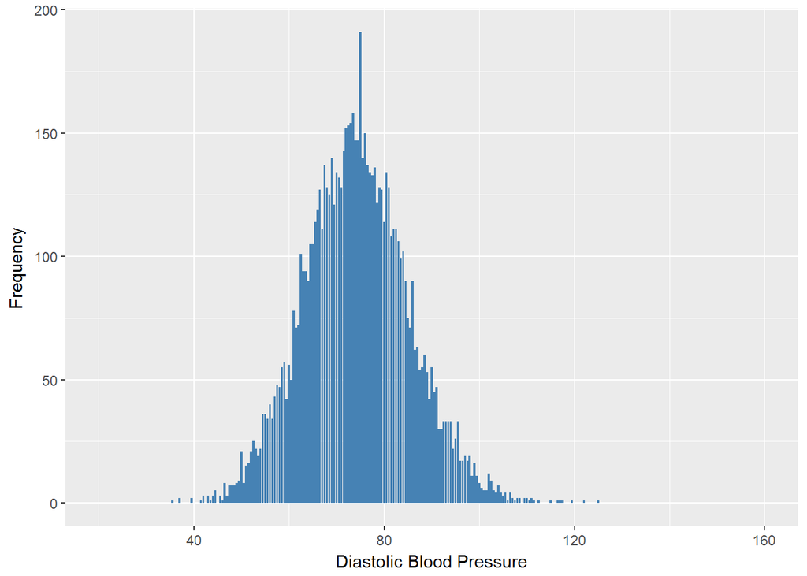

#### 2.1.6.4 Validation

### 2.1.7 Wave 7

There is no variable.

# 3 Quality estimation